# Analysis of the Adoption and Playing Time on STEAM

# Summary

- STEAM is not a platform only for collecting games as some assert. This impression may come from personal selective memory of such a behavior.
- “DOTA 2” occupies around 28% of total playing time of STEAM users, which occupies the biggest share in our data.
- Some titles such as “Counter-strike Global Offensive” has an extremely ‘long tail’ in the distribution of playing time.

# STEAM: Platform only for collecting?

From time to time, I heard that STEAM is not a platform for playing games, but only for collecting." That is, they buy games at STEAM, but do not play most of the games adopted. I also have some collection in STEAM that has not been played for a single time. I wonder if this is really a general behavior among STEAM users? I found a related data set in [Keggle](https://www.kaggle.com/tamber/steam-video-games). The data set may not be strongly reliable because details on data generation are not provided. For example, the observational range for the data is not specified. “Battle Ground”, recent one of the most popular titles, is not included in data. However, as of now, the data set is the best one that can be collected for me.

## Basic stats

Before exploring the main question, data is reorganized by titles and by individual players.

### By Titles

| var | n | max | min | mean | med | sd |
| --- | --- | --- | --- | --- | --- | --- |
| n_adopted | 5153 | 4841.0 | 1 | 24.99534 | 5.0 | 101.4039 |
| time | 5153 | 981599.6 | 0 | 668.40827 | 3.8 | 14991.7028 |

The above table shows that distribution of sales and playing time by title is very skewed to 0. That is, a small number of titles occupy most of the adoption and playing time of users. Consult below two figures.

[figure not shown]

### By individual players

| var | n | max | min | mean | med | sd |
| --- | --- | --- | --- | --- | --- | --- |
| n_adopted | 12393 | 1068 | 1 | 10.393045 | 2.0000000 | 35.6350785 |
| n_played | 12393 | 462 | 0 | 4.839587 | 1.0000000 | 14.7400739 |
| total_time | 12393 | 11754 | 0 | 277.923650 | 13.4000000 | 760.1482409 |
| sh_play | 12393 | 1 | 0 | 0.618359 | 0.6666667 | 0.3879193 |

[figure not shown]

### Playing over adoption

To answer the earlier question on the identity of STEAM, the number of titles played over the adopted is calculated for each player. Below figures show that 42.3% of users play all of the games adopted. 65.6% of players play more than half of their adoption.

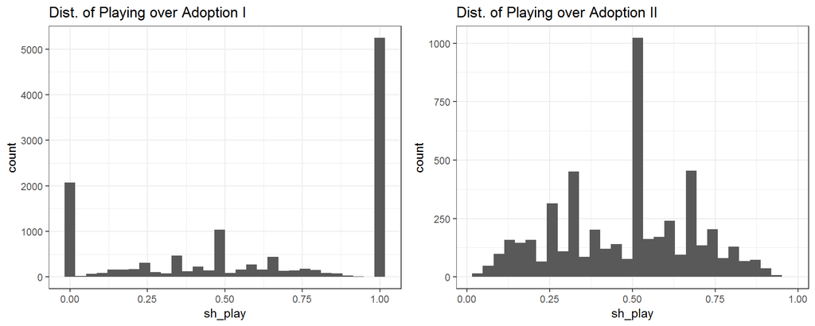

### Correlation between adoption and share of play

If the size of adoption is correlated with the share of play, some group of users might consider STEAM as the collecting-only platform. To check this point, the size of adoption and the share of play are plotted. The left panel of the below is plotted to the adoption level of $10^{1.5}(\approx 31.62)$ with some arbitrary noise. The right panel is plotted with the log-transformed adoption level.

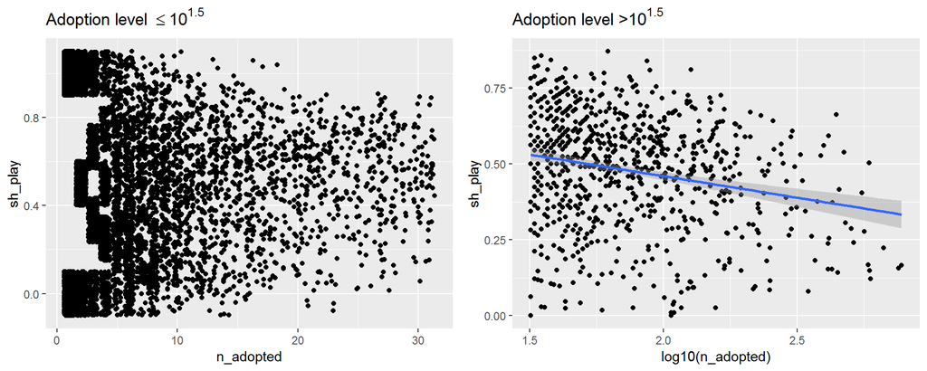

In conclusion, STEAM as the platform only for collecting games is not an adequate statement for its users. This impression comes from the selective memory of players who have some of the unplayed titles.

# The Pattern of Playing Time for Top Games

## Distribution of playing time for the top 20 titles

In exploring data interesting one is found. For the top 20 adopted games, distribution of (log-transformed) playing time is plotted. Some games have an extremely long tail, which means that most or considerable proportion of their players play heavily. Specifically, “Counter-Strike: Global Offensive”, “The Elder Scrolls V Skyrim”, “Sid Meiser’s Civilization V” are among them.

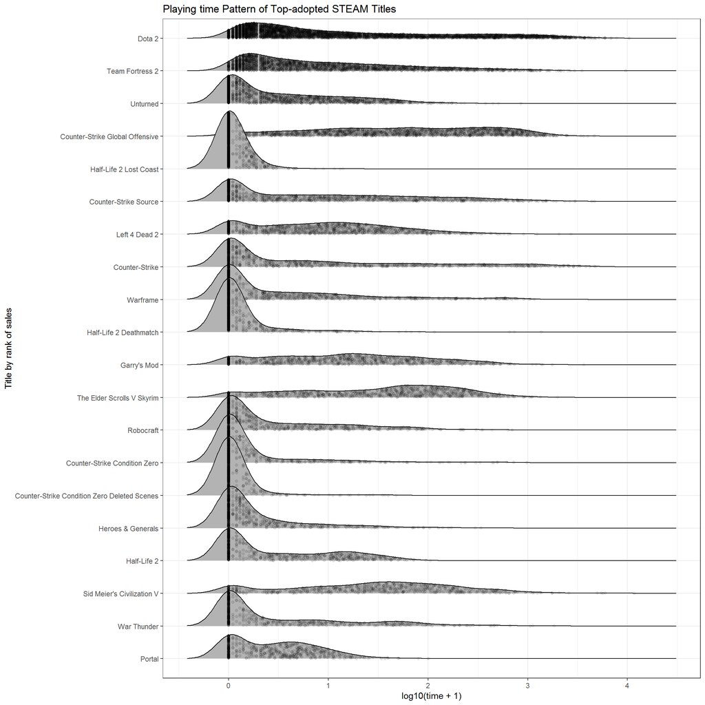

## Distribution of average playing time per title for users I

In a similar vein, the average playing time per title is examined by the top 20 users by adoption level. For some high-level adopting users such as 1, 7, 17, more than 3 hours are spent for many of adopted titles. A small fraction of games occupy most of playing time.

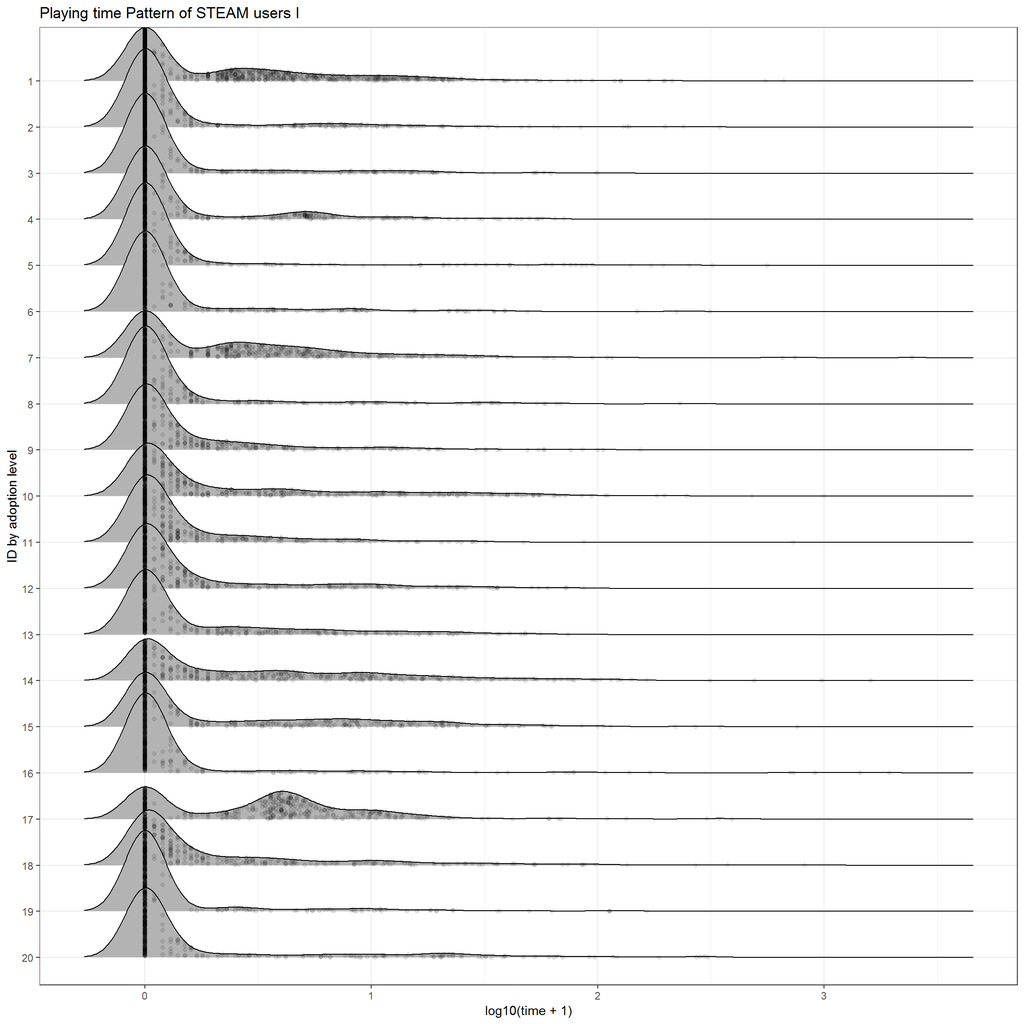

## Distribution of average playing time per title for users II

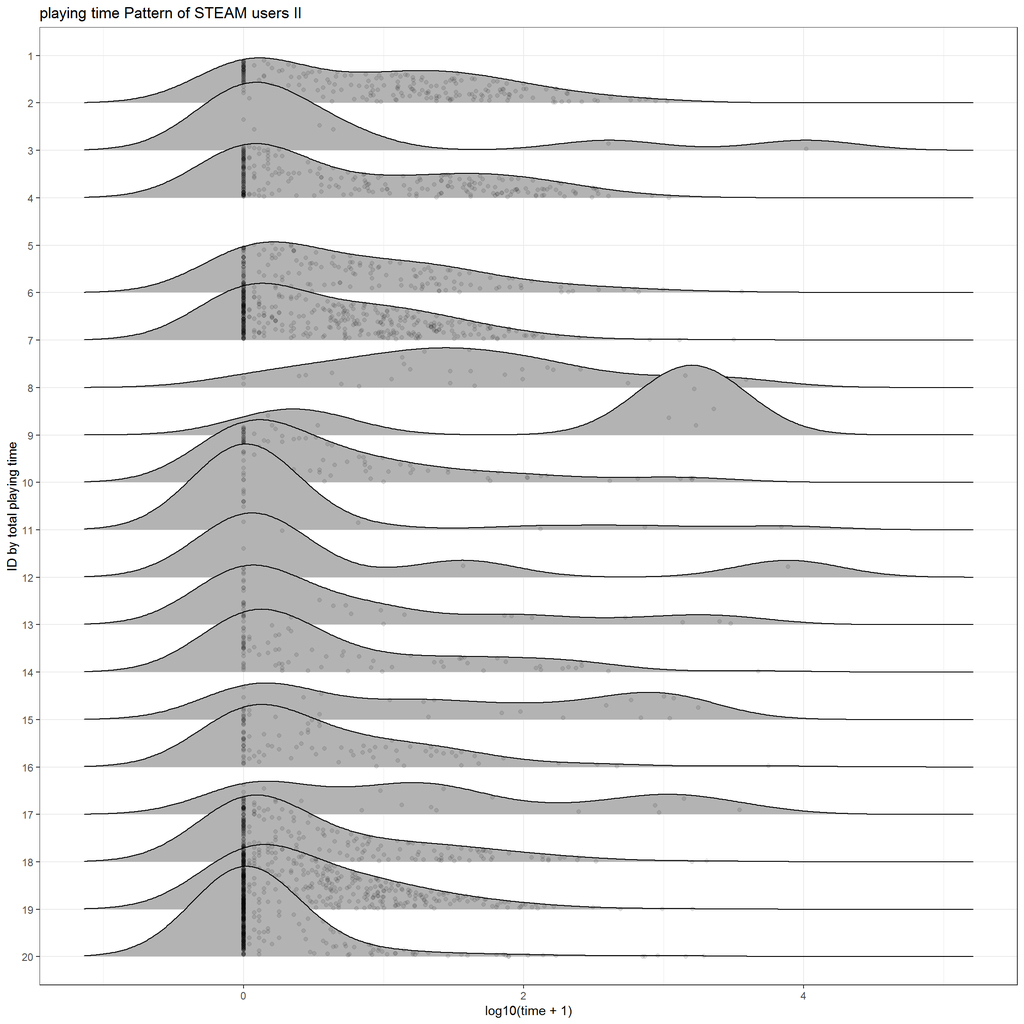

# Appendix

Tables for the top 20 titles and players are as follows:

## Playing time by individual players

| id | n_adopted | n_played | total_time | mean_time | sh_play |
| --- | --- | --- | --- | --- | --- |
| 1 | 1 | 1 | 11754.0 | 11754.00000 | 100.0% |
| 2 | 257 | 165 | 11649.7 | 70.60424 | 64.2% |
| 3 | 10 | 4 | 10853.2 | 2713.30000 | 40.0% |
| 4 | 276 | 156 | 10468.1 | 67.10321 | 56.5% |
| 5 | 2 | 1 | 9640.0 | 9640.00000 | 50.0% |
| 6 | 169 | 115 | 9545.3 | 83.00261 | 68.0% |
| 7 | 399 | 224 | 9426.2 | 42.08125 | 56.1% |
| 8 | 27 | 25 | 9417.6 | 376.70400 | 92.6% |
| 9 | 7 | 7 | 8172.9 | 1167.55714 | 100.0% |
| 10 | 102 | 54 | 8137.1 | 150.68704 | 52.9% |
| 11 | 27 | 5 | 7836.7 | 1567.34000 | 18.5% |
| 12 | 6 | 3 | 7801.9 | 2600.63333 | 50.0% |
| 13 | 32 | 16 | 7740.5 | 483.78125 | 50.0% |
| 14 | 85 | 50 | 7188.4 | 143.76800 | 58.8% |
| 15 | 24 | 17 | 7160.0 | 421.17647 | 70.8% |
| 16 | 95 | 50 | 7152.1 | 143.04200 | 52.6% |
| 17 | 18 | 14 | 7108.5 | 507.75000 | 77.8% |
| 18 | 246 | 117 | 6928.9 | 59.22137 | 47.6% |
| 19 | 474 | 255 | 6888.9 | 27.01529 | 53.8% |
| 20 | 449 | 64 | 6886.0 | 107.59375 | 14.3% |

## Adoption by individual players

| id | n_adopted | n_played | total_time | mean_time | sh_play |
| --- | --- | --- | --- | --- | --- |
| 1 | 1068 | 462 | 5710.8 | 12.361039 | 43.3% |
| 2 | 776 | 128 | 2272.4 | 17.753125 | 16.5% |
| 3 | 759 | 119 | 1217.7 | 10.232773 | 15.7% |
| 4 | 666 | 149 | 1372.9 | 9.214094 | 22.4% |
| 5 | 597 | 72 | 2729.3 | 37.906944 | 12.1% |
| 6 | 592 | 88 | 1394.0 | 15.840909 | 14.9% |
| 7 | 588 | 296 | 6003.9 | 20.283446 | 50.3% |
| 8 | 584 | 98 | 1220.3 | 12.452041 | 16.8% |
| 9 | 565 | 157 | 1456.8 | 9.278981 | 27.8% |
| 10 | 554 | 224 | 4841.3 | 21.612946 | 40.4% |
| 11 | 516 | 124 | 1456.8 | 11.748387 | 24.0% |
| 12 | 505 | 145 | 1344.4 | 9.271724 | 28.7% |
| 13 | 480 | 147 | 1225.2 | 8.334694 | 30.6% |
| 14 | 474 | 255 | 6888.9 | 27.015294 | 53.8% |
| 15 | 455 | 189 | 3941.2 | 20.852910 | 41.5% |
| 16 | 449 | 64 | 6886.0 | 107.593750 | 14.3% |
| 17 | 444 | 294 | 3009.2 | 10.235374 | 66.2% |
| 18 | 429 | 160 | 3216.6 | 20.103750 | 37.3% |
| 19 | 427 | 65 | 1029.1 | 15.832308 | 15.2% |
| 20 | 416 | 106 | 3055.3 | 28.823585 | 25.5% |

## Play time by titles

| title | n_adopted | n_played | time | sh_time |
| --- | --- | --- | --- | --- |
| Dota 2 | 4841 | 4841 | 981599.6 | 28.5% |
| Counter-Strike Global Offensive | 1412 | 1377 | 322762.6 | 9.4% |
| Team Fortress 2 | 2323 | 2323 | 173629.3 | 5.0% |
| Counter-Strike | 856 | 568 | 134254.1 | 3.9% |
| Sid Meier’s Civilization V | 596 | 554 | 99819.3 | 2.9% |
| Counter-Strike Source | 978 | 715 | 96070.5 | 2.8% |
| The Elder Scrolls V Skyrim | 717 | 677 | 70886.3 | 2.1% |
| Garry’s Mod | 731 | 666 | 49721.3 | 1.4% |
| Call of Duty Modern Warfare 2 - Multiplayer | 343 | 291 | 42007.9 | 1.2% |
| Left 4 Dead 2 | 951 | 801 | 33591.7 | 1.0% |
| Football Manager 2013 | 104 | 104 | 32308.6 | 0.9% |
| Football Manager 2012 | 80 | 79 | 30845.8 | 0.9% |
| Football Manager 2014 | 80 | 78 | 30574.8 | 0.9% |
| Terraria | 496 | 460 | 29946.8 | 0.9% |
| Warframe | 847 | 424 | 27068.6 | 0.8% |
| Football Manager 2015 | 79 | 77 | 24283.1 | 0.7% |
| Arma 3 | 161 | 157 | 24054.7 | 0.7% |
| Grand Theft Auto V | 273 | 269 | 22956.7 | 0.7% |
| Borderlands 2 | 429 | 386 | 22665.9 | 0.7% |
| Empire Total War | 263 | 214 | 21029.3 | 0.6% |

[^1]: Instead of using term ‘purchasing,’ we use ‘adoption’ as users’ behavior to choose games with or without paying. As there are many free-to-play games in our data sample, adoption is more proper world for our discussion.

Jun-Sok Huhh

2019-03-26 (current version in 2019-03-28)